# Income Dataset Creation

Author

Gustave Kenedi and Louis Sirugue

Published

April 11, 2023

## Packages

```r
packages <- c("here","tidyverse", "data.table", "furrr", "readxl", "janitor", "ggthemr", "furrr", "broom", "tidylog")
librarian::shelf(packages, quiet = TRUE)
rm(packages)
```

## Functions

```r
source(here("code_lib/useful_functions.R"))
```

## Params

```r
# figures
fig_height = 6
fig_width = (16/9)*fig_height
ggthemr("pale")

theme_update(text = element_text(size = 14),
             legend.title = element_text(face = "italic", size = 12),
             legend.text = element_text(size = 12),
             legend.background = element_rect(fill = alpha("white", .75)),
             plot.caption = element_text(size = 8, face = "italic", color = "#7d7d7d"))

# no scientific notation
options(scipen=999)

# path to data
data_path <- "~/Dropbox/3resources/data/psid/"
```

## Load data

```r
# PSID variables dictionary
psid_vars <- read_excel(paste0(data_path, "fims/psid.xlsx")) %>%
  clean_names() %>%
  mutate(var_id = 1:n()) %>%
  pivot_longer(cols = -c(var_id, type, category, text, head_wife, var_count),
               names_prefix = "y",
               names_to = "year",
               values_to = "variable")

# individual file
ind_2019 <- fread(paste0(data_path, "ind2019er/IND2019ER.csv"))
ind_2019 <- ind_2019 %>%
  mutate(fam_id_68 = ER30001,
         person_num_68 = ER30002,
         ind_id_68 = fam_id_68*1000 + person_num_68,
         gender = case_when(ER32000 == 1 ~ "Male",
                            ER32000 == 2 ~ "Female"))
setDT(ind_2019)

# family files 1968-20219
years <- c(1968:1997, seq(1999, 2019, 2))
for (i in years) {
  print(i)

  if (i %in% 1968:1993) {
    file_path <- paste0(data_path, "fam", i, "/FAM", i)
  } else {
    file_path <- paste0(data_path, "fam", i, "er", "/FAM", i, "ER")
  }

  assign(paste0("fam_", i), fread(paste0(file_path, ".csv")))
}

# CPI U (series ID: CUUR0000SA0)
cpi_u <- read_excel(paste0(data_path, "cpi_u/cpi_u_1967_2021.xlsx"), skip = 11) %>% clean_names()

gc()
```

## Income variables

Define income variables as closely as to how they are defined in our paper:

- **reference person + partner**
  - *labor income:* “money income from labor”  
    $\rightarrow$ more comprehensive than wage because it corresponds to the “sum of the actual amounts of labor part of farm income and business income, bonuses, overtime, commissions, professional practice, labor part of income from roomers and boarders or business income plus wages,”  
    $\rightarrow$ note that wages are only available for reference persons and not for partners, therefore not usable for us. Probably not a major concern since labor income captures mostly wages anyways.  
    $\rightarrow$ one difference with our paper is that this more comprehensive definition of labor incomes will include self-employment income.
  - *taxable income* + *total transfer income* (so we can compare labor-family income RRC with family income-family income RRC (and other intergenerational stats))  
    $\rightarrow$ total transfer income: aid to dependent children + aid to dependent children with unemployed fathers + other welfare + social security + retirement + UI + alimony + help from relatives + income from other sources.  
    $\rightarrow$ here again the definition is a bit more comprehensive because total transfer income includes transfers we exclude in our definition.  
    $\rightarrow$ issue is that UI + retirement + alimony is generally available only for reference person and not consistently reported rendering the analysis a bit more complicated.
- **children**
  - *taxable income* + *total transfer income*  
    $\rightarrow$ total transfer income: aid to dependent children + aid to dependent children with unemployed fathers + other welfare + social security + retirement + UI + alimony + help from relatives + income from other sources

```r
# initiate variable used data.frame ----
used_vars <- as_tibble(years)
# -----

# family interview id ----
psid_vars %>% filter(var_id == 8746) %>% count(text)
```

| text | n |
| --- | --- |
| 01>SURVEY INFORMATION\r\n02>Interview Information\r\n03>family interview number (ID): | 41 |

```r
fam_id_vars <- psid_vars %>% filter(var_id == 8746) %>% pull(variable)
used_vars <- bind_cols(used_vars, fam_id_vars = fam_id_vars)
# ----

# family interview number ----
psid_vars %>% filter(var_id == 419) %>% count(text)
```

| text | n |
| --- | --- |
| 01>SURVEY INFORMATION:\r\n02>Interview Information\r\n03>id (interview) number: | 41 |

```r
itw_num_vars <- psid_vars %>% filter(var_id == 419) %>% pull(variable)
used_vars <- bind_cols(used_vars, itw_num_vars = itw_num_vars)
# ----

# relation to head ----
psid_vars %>% filter(var_id == 422) %>% count(text)
```

| text | n |
| --- | --- |
| 01>SURVEY INFORMATION:\r\n02>Interview Information\r\n03>relationship to head/reference person: | 41 |

```r
rel_head_vars <- psid_vars %>% filter(var_id == 422) %>% pull(variable)
used_vars <- bind_cols(used_vars, rel_head_vars = rel_head_vars)
# ----

# obtain "head/reference and spouse taxable income" for all families
# taxable income of head and wife ----
psid_vars %>% filter(var_id == 5543) %>% count(text)
```

| text | n |
| --- | --- |
| 01>INCOME\r\n02>Family Money\r\n03>taxable\r\n04>head/reference person and spouse, whether:\r\n05>amount: | 41 |

```r
tax_inc_vars <- psid_vars %>% filter(var_id == 5543) %>% pull(variable)
used_vars <- bind_cols(used_vars, tax_inc_vars = tax_inc_vars)

# accuracy of taxable income
psid_vars %>% filter(var_id == 5541) %>% count(text)
```

| text | n |
| --- | --- |
| 01>INCOME\r\n02>Family Money\r\n03>taxable\r\n04>head/reference person and spouse, whether:\r\n05>amount:\r\n06>accuracy code: | 41 |

```r
accu_tax_inc_vars <- psid_vars %>% filter(var_id == 5541) %>% pull(variable)
used_vars <- bind_cols(used_vars, accu_tax_inc_vars = accu_tax_inc_vars)
accu_tax_inc_vars <- accu_tax_inc_vars[!is.na(accu_tax_inc_vars)] # missing in a number of years
# -----

# total transfers of head and wife ----
psid_vars %>% filter(var_id == 6669) %>% count(text)
```

| text | n |
| --- | --- |
| 01>INCOME\r\n02>Transfers\r\n03>total, whether:\r\n04>head/reference person and spouse: | 41 |

```r
transfers_vars <- psid_vars %>% filter(var_id == 6669) %>% pull(variable)
used_vars <- bind_cols(used_vars, transfers_vars = transfers_vars)
transfers_vars <- transfers_vars[!is.na(transfers_vars)] # missing in 1968 and 1969
# ----

# head's labor income ----
psid_vars %>% filter(var_id == 5643) %>% count(text)
```

| text | n |
| --- | --- |
| 01>INCOME\r\n02>Labor\r\n03>head/reference person\r\n04>total (includes wages and other labor): | 41 |

```r
head_lab_inc_vars <- psid_vars %>% filter(var_id == 5643) %>% pull(variable)
used_vars <- bind_cols(used_vars, head_lab_inc_vars = head_lab_inc_vars)
# ----

# accuracy of head's labor income ----
psid_vars %>% filter(var_id == 5645) %>% count(text)
```

| text | n |
| --- | --- |
| 01>INCOME\r\n02>Labor\r\n03>head/reference person\r\n04>wages and salaries:\r\n05>reported:\r\n06>accuracy code: | 41 |

```r
accu_head_lab_inc_vars <- psid_vars %>% filter(var_id == 5645) %>% pull(variable)
accu_head_lab_inc_vars[which(years %in% 1968:1969)] <- c("V85", "V515") # accuracy variables for 1968 and 1969 (no idea why they are not with the other values in the excel spredsheet)
accu_head_lab_inc_vars[which(years %in% 1997:1999)] <- c("ER12081", "ER16464") # accuracy variables for 1997 and 1999
used_vars <- bind_cols(used_vars, accu_head_lab_inc_vars = accu_head_lab_inc_vars)
accu_head_lab_inc_vars <- accu_head_lab_inc_vars[!is.na(accu_head_lab_inc_vars)]
# ----

# wife labor income ----
psid_vars %>% filter(var_id == 5750) %>% count(text)
```

| text | n |
| --- | --- |
| 01>INCOME\r\n02>Labor\r\n03>spouse\r\n04>total (includes wages and other labor): | 41 |

```r
psid_vars %>% filter(var_id == 5766) %>% count(text)
```

| text | n |
| --- | --- |
| 01>INCOME\r\n02>Labor\r\n03>spouse\r\n04>total excluding farm and business: | 41 |

```r
spouse_lab_inc_vars <- c(psid_vars %>% filter(var_id == 5750 & year < 1994) %>% pull(variable),
                         psid_vars %>% filter(var_id == 5766 & year >= 1994) %>% pull(variable))
used_vars <- bind_cols(used_vars, spouse_lab_inc_vars = spouse_lab_inc_vars)

# accuracy wife labor income
psid_vars %>% filter(var_id == 5745) %>% count(text)
```

| text | n |
| --- | --- |
| 01>INCOME\r\n02>Labor\r\n03>spouse\r\n04>total (includes wages and other labor):\r\n05>accuracy code: | 41 |

```r
psid_vars %>% filter(var_id == 5751) %>% count(text)
```

| text | n |
| --- | --- |
| 01>INCOME\r\n02>Labor\r\n03>spouse\r\n04>total excluding farm and business:\r\n05>accuracy code: | 41 |

```r
accu_spouse_lab_inc_vars <- c(psid_vars %>% filter(var_id == 5745 & year < 1994) %>% pull(variable),
                              psid_vars %>% filter(var_id == 5751 & year >= 1994) %>% pull(variable))
used_vars <- bind_cols(used_vars, accu_spouse_lab_inc_vars = accu_spouse_lab_inc_vars)
accu_spouse_lab_inc_vars <- accu_spouse_lab_inc_vars[!is.na(accu_spouse_lab_inc_vars)]
# ----

# obtain income variables ----
df_list <- ls(pattern = "fam_\\d")
inc_all <- map_dfr(df_list,
                   ~ get(.x) %>%
                     mutate(year_psid = as.numeric(str_extract(.x, "\\d+")),
                            year_inc = as.numeric(str_extract(.x, "\\d+")) - 1, # -1 because income reported in year n corresponds to income earned in year n - 1
                            across(any_of(fam_id_vars), ~ .x, .names = "itw_num"),
                            across(any_of(tax_inc_vars), ~ .x, .names = "family_tax_income"),
                            across(any_of(accu_tax_inc_vars), ~ .x, .names = "accuracy_family_tax_income"),
                            across(any_of(transfers_vars), ~ .x, .names = "family_transfers_income"),
                            across(any_of(head_lab_inc_vars), ~ .x, .names = "head_labor_income"),
                            across(any_of(accu_head_lab_inc_vars), ~ .x, .names = "accuracy_head_labor_income"),
                            across(any_of(spouse_lab_inc_vars), ~ .x, .names = "wife_labor_income"),
                            across(any_of(accu_spouse_lab_inc_vars), ~ .x, .names = "accuracy_wife_labor_income")) %>%
                     select(itw_num, year_psid, year_inc, family_tax_income, head_labor_income, wife_labor_income, any_of(c("family_transfers_income", "accuracy_family_tax_income", "accuracy_head_labor_income", "accuracy_wife_labor_income"))))
setDT(inc_all)
# ----

inc_all %>% head
```

| itw_num | year_psid | year_inc | family_tax_income | head_labor_income | wife_labor_income | accuracy_family_tax_income | accuracy_head_labor_income | accuracy_wife_labor_income | family_transfers_income |
| --- | --- | --- | --- | --- | --- | --- | --- | --- | --- |
| 1 | 1968 | 1967 | 5614 | 1711 | 3903 | 0 | 0 | 0 | NA |
| 2 | 1968 | 1967 | 0 | 0 | 0 | 0 | 0 | 0 | NA |
| 3 | 1968 | 1967 | 0 | 0 | 0 | 0 | 0 | 0 | NA |
| 4 | 1968 | 1967 | 5450 | 3280 | 0 | 0 | 0 | 0 | NA |
| 5 | 1968 | 1967 | 7900 | 5800 | 2100 | 0 | 0 | 0 | NA |
| 6 | 1968 | 1967 | 6318 | 6100 | 168 | 0 | 0 | 0 | NA |

```r
# compute number of heads and wife/"wife" in household in each year ----
# obtain long version of individual data with interview number and relation to household head
ind_2019_long <- ind_2019 %>%
  select(ind_id_68, gender, all_of(c(itw_num_vars, rel_head_vars))) %>%
  rename_with(~ map2_chr(itw_num_vars, years, ~ paste0(.x, "_itw_", .y)), all_of(itw_num_vars)) %>%
  rename_with(~ map2_chr(rel_head_vars, years, ~ paste0(.x, "_rel_", .y)), all_of(rel_head_vars)) %>%
  pivot_longer(cols = -c(ind_id_68, gender),
               names_to = c(".value", "year"),
               names_pattern = ".(itw|rel)_(\\d+)") %>%
  rename(itw_num = itw,
         rel_head = rel) %>%
  mutate(year = as.numeric(year)) %>%
  filter(substr(rel_head, 1, 1) != 0)

# merge income data
ind_2019_long <- ind_2019_long %>%
  left_join(inc_all %>% rename(year = year_psid))

# compute number of household "adults"
# equal 1 if only head
# equal 2 if head + "wife"
ind_2019_long <- ind_2019_long %>%
  group_by(year, itw_num, head_labor_income, wife_labor_income) %>%
  summarise(n_adults = sum(substr(rel_head, 1, 1) %in% 1:2)) %>%
  ungroup()
# 40.6% of observations are for households with only 1 "adult"
ind_2019_long %>% count(n_adults) %>% count_to_pct()
```

| n_adults | n | pct |
| --- | --- | --- |
| 0 | 1 | 0.000003310184 |
| 1 | 122757 | 0.406348271091 |
| 2 | 178659 | 0.591394183344 |
| 3 | 619 | 0.002049003966 |
| 4 | 62 | 0.000205231415 |

```r
# add number of household "adults" to income data
inc_all <- inc_all %>%
  left_join(ind_2019_long %>% select(year_psid = year, itw_num, n_adults))
# ----

# generate family labor income
inc_all[, family_labor_income := head_labor_income + wife_labor_income]

# generate family total income = family taxable income + transfers
inc_all[, family_total_income := family_tax_income + family_transfers_income]
# total income missing for 1968 and 1969 since no transfers variable available for these years
inc_all %>% count(year_inc, is.na(family_total_income))
```

| year_inc | is.na(family_total_income) | n |
| --- | --- | --- |
| 1967 | TRUE | 4802 |
| 1968 | TRUE | 4460 |
| 1969 | FALSE | 4645 |
| 1970 | FALSE | 4840 |
| 1971 | FALSE | 5060 |
| 1972 | FALSE | 5285 |
| 1973 | FALSE | 5517 |
| 1974 | FALSE | 5725 |
| 1975 | FALSE | 5862 |
| 1976 | FALSE | 6007 |

[output cut: 31 more lines]

```r
# for 61.6% of cases, family taxable income = head labor income + wife labor income
inc_all %>% count(family_tax_income == family_labor_income) %>% count_to_pct()
```

| family_tax_income == family_labor_income | n | pct |
| --- | --- | --- |
| FALSE | 115948 | 0.3838105 |
| TRUE | 186149 | 0.6161895 |

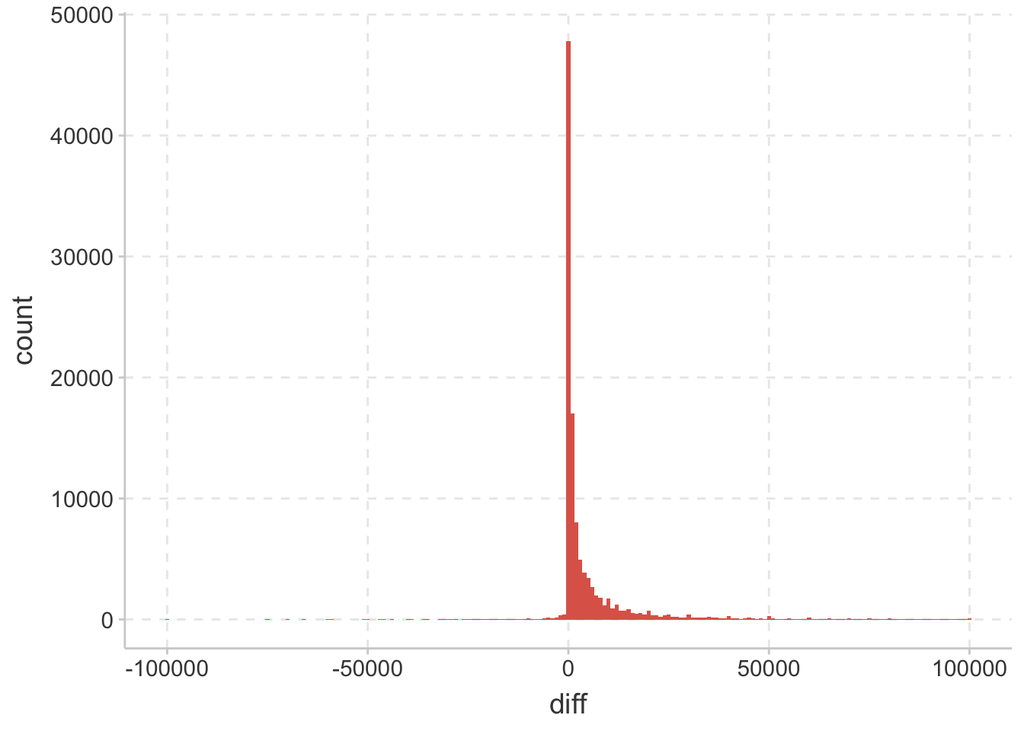

```r
# when there is a difference it is small
inc_all %>%
  filter(family_tax_income != 9999999 | family_labor_income != 19999998 | head_labor_income == 99999 | wife_labor_income == 99999) %>%
  mutate(diff = family_tax_income - family_labor_income) %>%
  filter(abs(diff) <= 100000 & diff != 0) %>%
  ggplot(aes(x = diff)) +
  geom_histogram(binwidth = 1000)
```

```r
# 56.4% when only keeping non-zero family incomes
inc_all[family_tax_income != 0] %>% count(family_tax_income == family_labor_income) %>% count_to_pct()
```

| family_tax_income == family_labor_income | n | pct |
| --- | --- | --- |
| FALSE | 115937 | 0.4363521 |
| TRUE | 149759 | 0.5636479 |

```r
# merge price level data
inc_all <- inc_all %>%
  left_join(cpi_u %>% select(year_inc = year, base_2019))

# generate real income variables (in 2019 dollars)
inc_vars <- c("family_total_income", "family_tax_income", "family_transfers_income", "family_labor_income", "head_labor_income", "wife_labor_income")
inc_all <- inc_all %>%
  mutate(across(all_of(inc_vars), ~ .x * (1 + base_2019), .names = "{.col}_real"))

# generate income variables divided by number of adults in household
inc_all <- inc_all %>%
  mutate(across(all_of(paste0(inc_vars, "_real")), ~ .x/n_adults, .names = "{.col}_n"))
```

## Display and export used variables

```r
used_vars
```

| value | fam_id_vars | itw_num_vars | rel_head_vars | tax_inc_vars | accu_tax_inc_vars | transfers_vars | head_lab_inc_vars | accu_head_lab_inc_vars | spouse_lab_inc_vars | accu_spouse_lab_inc_vars |
| --- | --- | --- | --- | --- | --- | --- | --- | --- | --- | --- |
| 1968 | V3 | ER30001 | ER30003 | V76 | V87 | NA | V74 | V85 | V75 | V86 |
| 1969 | V442 | ER30020 | ER30022 | V518 | V519 | NA | V514 | V515 | V516 | V517 |
| 1970 | V1102 | ER30043 | ER30045 | V1205 | V1206 | V1220 | V1196 | V1192 | V1198 | V1199 |
| 1971 | V1802 | ER30067 | ER30069 | V1906 | V1907 | V1922 | V1897 | V1893 | V1899 | V1900 |
| 1972 | V2402 | ER30091 | ER30093 | V2507 | V2508 | V2523 | V2498 | V2494 | V2500 | V2501 |
| 1973 | V3002 | ER30117 | ER30119 | V3060 | V3061 | V3076 | V3051 | V3047 | V3053 | V3054 |
| 1974 | V3402 | ER30138 | ER30140 | V3472 | V3473 | V3488 | V3463 | V3459 | V3465 | V3466 |
| 1975 | V3802 | ER30160 | ER30162 | V3872 | V3873 | V3889 | V3863 | V3859 | V3865 | V3866 |
| 1976 | V4302 | ER30188 | ER30190 | V4386 | V4387 | V4404 | V5031 | V4374 | V4379 | V4380 |
| 1977 | V5202 | ER30217 | ER30219 | V5297 | V5298 | V5316 | V5627 | V5284 | V5289 | V5290 |

[output cut: 31 more lines]

```r
fwrite(used_vars, here("data/used_vars_income_data.csv"))
```

## Export income dataset

```r
fwrite(inc_all, here("data/inc_all.csv"))
```